# Lab 5

Eric Miao, Sabrina Peng, Fernando Vazquez

CS7324, Fall 2020

## 0. Dataset Introduction and Description

Obesity is a medical issue where excessive amounts of body fat result in increased risk of diseases and health problems, including but not limited to heart disease, diabetes, and high blood pressure [[1](https://www.mayoclinic.org/diseases-conditions/obesity/symptoms-causes/syc-20375742#:~:text=Obesity%20is%20a%20complex%20disease,blood%20pressure%20and%20certain%20cancers)]. Worldwide obesity has nearly tripled since 1975, and most of the world's population lives in countries where being overweight or obese kills more people than being underweight - it's not just a first-world country problem anymore [[2](https://www.who.int/news-room/fact-sheets/detail/obesity-and-overweight)]. The rise of this problem can be attributed to a variety of trends, including increasing use of technology while sedentary, less time spent on physical activities, and increased intake of foods that are high in fat and sugar. Although there have been some programs that encourage healthy living to stave off obesity (Michelle Obama's `Let's Move!` campaign comes to mind), obesity often gets much less attention and resources than other acute and chronic diseases.

The dataset we picked for our logistic regression extension task contains data for estimation of obesity levels in individuals from the countries of Mexico, Peru, and Colombia, based on collected information on eating habits, lifestyle choices, and physical characteristics [[3](https://archive.ics.uci.edu/ml/datasets/Estimation+of+obesity+levels+based+on+eating+habits+and+physical+condition+)]. This information was collected via an online survey and preprocessed to handle missing and atypical data. There were 485 initial responses, and respondents were labelled with one of 7 weight categories (`Underweight`, `Normal`, `Overweight I`, `Overweight II`, `Obesity I`, `Obesity II`, and `Obesity III`) based on WHO standards of BMI and Mexican normativity, using the equation below.

\begin{equation*} BMI = \frac{weight}{height^2} \end{equation*}

Interestingly, through the 485 initial responses, the researchers collecting the data discovered the dataset was extremely imbalanced (with a majority of the respondents falling into the normal category), so they decided to generate synthetic data (77% of the final dataset) using the `Weka`) data mining tool and `SMOTE` (synthetic minority over-sampling technique). After using this technique, a more balanced distribution was achieved. Therefore, much of the data processing was already handled for us by the researchers, and we started off with a relatively even dataset (as we will see below) [[4](https://www.sciencedirect.com/science/article/pii/S2352340919306985?via%3Dihub)].

The goal is to use the 17 different attributes collected to predict what category of weight (underweight, normal, some category of overweight, or some category of obese) someone will be given different factors about their eating, activity, and lives. This may provide a better model of obesity than the simple `BMI` model described above and typically used to diagnose obesity.

## 1. Data Preparation

### 1.1 Data Exploration

```python
import pandas as pd
import numpy as np

# load the dataset and view first few rows of training dataset
df = pd.read_csv('ObesityDataSet_raw_and_data_sinthetic.csv')
df.head()
```

|  | Gender | Age | Height | Weight | family_history_with_overweight | FAVC | FCVC | NCP | CAEC | SMOKE | CH2O | SCC | FAF | TUE | CALC | MTRANS | NObeyesdad |
| --- | --- | --- | --- | --- | --- | --- | --- | --- | --- | --- | --- | --- | --- | --- | --- | --- | --- |
| 0 | Female | 21.0 | 1.62 | 64.0 | yes | no | 2.0 | 3.0 | Sometimes | no | 2.0 | no | 0.0 | 1.0 | no | Public_Transportation | Normal_Weight |
| 1 | Female | 21.0 | 1.52 | 56.0 | yes | no | 3.0 | 3.0 | Sometimes | yes | 3.0 | yes | 3.0 | 0.0 | Sometimes | Public_Transportation | Normal_Weight |
| 2 | Male | 23.0 | 1.80 | 77.0 | yes | no | 2.0 | 3.0 | Sometimes | no | 2.0 | no | 2.0 | 1.0 | Frequently | Public_Transportation | Normal_Weight |
| 3 | Male | 27.0 | 1.80 | 87.0 | no | no | 3.0 | 3.0 | Sometimes | no | 2.0 | no | 2.0 | 0.0 | Frequently | Walking | Overweight_Level_I |
| 4 | Male | 22.0 | 1.78 | 89.8 | no | no | 2.0 | 1.0 | Sometimes | no | 2.0 | no | 0.0 | 0.0 | Sometimes | Public_Transportation | Overweight_Level_II |

```python
# rename columns
target_variable_name = 'Obesity_Level' # rename obesity column
df.rename(columns={'NObeyesdad': target_variable_name}, inplace=True)

target_variable_name = 'Family_History' # rename family history column
df.rename(columns={'family_history_with_overweight': target_variable_name}, inplace=True)
```

```python
df.Obesity_Level.unique()
```

```
array(['Normal_Weight', 'Overweight_Level_I', 'Overweight_Level_II',
       'Obesity_Type_I', 'Insufficient_Weight', 'Obesity_Type_II',
       'Obesity_Type_III'], dtype=object)
```

```python
print("Features:", list(df.columns))
```

```
Features: ['Gender', 'Age', 'Height', 'Weight', 'Family_History', 'FAVC', 'FCVC', 'NCP', 'CAEC', 'SMOKE', 'CH2O', 'SCC', 'FAF', 'TUE', 'CALC', 'MTRANS', 'Obesity_Level']
```

Here is a legend of the different column features collected and present within the dataset:

Food consumption:

- Frequent consumption of high caloric food (FAVC)
- Frequency of consumption of vegetables (FCVC)
- Number of main meals (NCP)
- Consumption of food between meals (CAEC)
- Consumption of water daily (CH20)
- Consumption of alcohol (CALC)

Lifestyle conditions:

- Calories consumption monitoring (SCC)
- Physical activity frequency (FAF)
- Time using technology devices (TUE)
- Transportation used (MTRANS)

Physical characteristics:

- Gender
- Age
- Height
- Weight

References:

- https://www.sciencedirect.com/science/article/pii/S2352340919306985?via%3Dihub

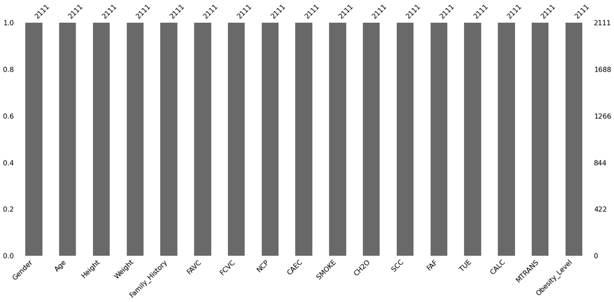

```python
import matplotlib.pyplot as plt
import missingno as msno

msno.bar(df)
plt.show()
```

As we can see, there are no missing values in the dataset we chose, so there is no need for data imputation or removal of instances with missing values.

### 1.2 Cross-Product Features

A feature cross is a synthetic feature formed by crossing two or more features that may be correlated with the target variable. Crossing combinations of features can provide predictive abilities beyond what those features can provide individually.

```python
print("Features:", list(df.columns))
```

```
Features: ['Gender', 'Age', 'Height', 'Weight', 'Family_History', 'FAVC', 'FCVC', 'NCP', 'CAEC', 'SMOKE', 'CH2O', 'SCC', 'FAF', 'TUE', 'CALC', 'MTRANS', 'Obesity_Level']
```

```python
# define numeric and categorical columns to be used later

numerical_cols = ['Age', 'Height', 'Weight', 'FCVC', 'NCP', 'CH2O', 'FAF', 'TUE']
categorical_cols = ['Gender', 'Family_History', 'FAVC', 'SMOKE', 'SCC', 'CAEC', 'CALC', 'MTRANS']
```

```python
cross_columns_all = [
    ['FAVC', 'CAEC'],
    ['Family_History', 'CALC'],
    ['FAVC', 'SCC'],
    ['Gender', 'SMOKE'],
    ['Gender', 'Family_History']
]

cross_columns_subset = [
    ['FAVC', 'CAEC'],
    ['Family_History', 'CALC'],
    ['FAVC', 'SCC']
]
```

#### Cross-Product Feature 1: Consumption of food between meals (CAEC) - Frequent consumption of high caloric food (FAVC)

The consumption of food between meals and the frequency of one consuming high-calorie food can help us know the eating habit of an individual. Typically, if one frequently consumes high caloric food and still consumes food between meals, he or she would take in more calories in a day compared to another person who is having a normal diet. Therefore, the individual has a higher chance of obesity.

#### Cross-Product Feature 2: Family_History - Consumption of alcohol (CALC)

People with a family history of obesity had a higher BMI and were at increased risk of obesity. Also, research shows that drinking alcohol increases appetite, and so can lead to overeating and weight gain. To be more specific, drinking more than seven times per week was associated with the risk of weight gain and the development of overweight. The product of Family History with Consumption of alcohol can help us identify one's risk of obesity. If one has a family history of obesity and consume alcohol regularly, he/she will have a higher risk of being obese.

#### Cross-Product Feature 3: Gender - Smoking (SMOKE)

Research has shown that current smokers have a lower mean body mass index (BMI) than never and former smokers, with former smokers having the highest mean BMI. Therefore, people who smoke often are more likely to be obese in a long run. Generally, males tend to use all tobacco products at higher rates than women. The product between Gender and Smoke can give us a model for how likely one will be obese from individual gender and smoking habit.

#### Cross-Product Feature 4: Frequent consumption of high caloric food (FAVC) - Calorie consumption monitoring (SCC)

Frequent consumption of high caloric food (FAVC) - Calories consumption monitoring (SCC) Tracking calorie intake can help one to identify which eating patterns he/she needs to modify to successfully lose weight. Similarly, an individual is more likely to be obese if he/she consumes high caloric food frequently. The product of frequent consumption of high caloric food (FAVC) with calorie consumption monitoring (SCC) can model the relationship of one’s eating habits. If one consumes high-calorie food very often and does track the calorie intake, he/she has a higher chance to be obese. On the other hand, if one consume high-calorie food less often and keep taking his/her calories, he/she is less likely to be obese.

#### Cross-Product Feature 5: Gender - Family History

The prevalence of overweight and obesity among men and women varies greatly between countries, but overall, more women are obese than men. Similarly, people with a family history of obesity had a higher BMI and were at increased risk of obesity. Using the product of both gender and family history, we can identify one’s risk of obesity. If one identified as female and has a family history of obesity, she would more likely to be obese.

### 1.3 Metric for Performance Evaluation

For evaluation, we want to know how precise the model is out of those predicted for each obesity category, how many of them are truly in that obesity category. We also want to know the fraction of the testing sample from a class that is correctly predicted by the model. In this scenario, the F-1 score is a great choice here because it is the harmonic mean of the precision and recall, which incorporates what we want to know.

Accuracy is usually the first metric to be used, but since we want to get a better measure of incorrectly classified cases, accuracy as a metric does not penalize wrong classifications enough. In our case, classifying someone as the wrong obesity / weight category could be very bad, especially if our model was used to dispense health data. A wrong classification could result in patients drastically changing their lifestyle and health, possibly to their detriment. Using the F-1 score will shed more light onto the false positives and negatives so that we can avoid these real-world ramifications.

The F-1 score is typically used for binary classification problems, but we can use it in a multi-class classification problem as well. To do this, we specify an averaging method so that we can get a single F-1 score for easier comparison. For this project, we are using the `macro` averaging method, which treats "all classes as equal, independent of the sample sizes." This ensures that the F-1 score of the majority class does not dominate.

If we had more time, we could have implemented a custom confusion matrix metric, where we could levy penalties for more egregious errors (i.e. classifying someone as `Obesity_Type_III` (the worst obesity level) if he / she was actually at the `Normal_Weight` level should be penalized much worse than classifying that person as `Overweight_Type_1` (since `Overweight_Type_1` is only the category right above `Normal_Weight`).

References:

- https://medium.com/analytics-vidhya/accuracy-vs-f1-score-6258237beca2
- https://www.baeldung.com/cs/multi-class-f1-score

\begin{equation*} {F1-Score} = \frac {2*Precision*Recall}{(Precision+Recall)}\end{equation*}

### 1.4 Train-Test Split, Cross Validation

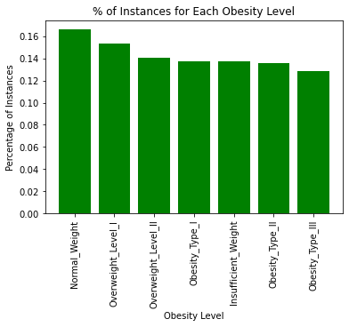

```python
# plot bar chart to show class balance / imbalance

x = df.Obesity_Level.unique()
y = df.Obesity_Level.value_counts() / len(df)
x_pos = [i for i, _ in enumerate(x)]

plt.bar(x_pos, y, color='green')
plt.xlabel("Obesity Level")
plt.ylabel("Percentage of Instances")
plt.title("% of Instances for Each Obesity Level")

plt.xticks(x_pos, x, rotation=90)

plt.show()
```

As we can see, there is an pretty even distribution of every category in the dataset, so an 80/20 split seems to be proper in this case. But we decided to use StratifiedShuffleSplit due to our dataset being relatively small. In addition, this will help us prevent bias from occurring in our train/test set. Since StratifiedShuffleSplit will preserve the ratio of each class sample, we can prevent one class from being over/under represented in any of the train/test set splits. The stratification will be useful with more real-world training data as well, where there will be more severe class imbalance than in the current dataset, which has been artificially augmented using SMOTE to preserve class balance.

```python
# create and save cross-val splits
from sklearn.model_selection import StratifiedShuffleSplit

X = df.loc[:, df.columns != 'Obesity_Level']
y = df['Obesity_Level']
n_splits = 5

# encode target values
from sklearn.preprocessing import LabelEncoder, OneHotEncoder

y_encoder = LabelEncoder()
y = y_encoder.fit_transform(y)

y_ohe_encoder = OneHotEncoder(sparse=False)
y_enc = y.reshape(len(y), 1)
y_temp = y_ohe_encoder.fit(y_enc)

sss = StratifiedShuffleSplit(n_splits=n_splits, test_size=0.2, random_state=4)

splits = []
for train_index, test_index in sss.split(X, y):
    splits.append((X.loc[train_index], X.loc[test_index], y[train_index], y[test_index]))
```

### 1.5 Helper Functions and Imports

```python
# necessary imports

from sklearn import metrics as mt
import tensorflow as tf
from tensorflow import keras

from tensorflow.keras.layers import Dense, Activation, Input, Embedding, Flatten, concatenate
from tensorflow.keras.models import Model

import seaborn as sn
```

```python
from copy import deepcopy
from sklearn.preprocessing import StandardScaler

def preprocess_data(X_train_orig, X_test_orig, y_train_orig, y_test_orig):
    X_train = deepcopy(X_train_orig)
    X_test = deepcopy(X_test_orig)

    # scale continuous numeric variables
    for col in numerical_cols:
        X_train[col] = X_train[col].astype(np.float32)
        X_test[col] = X_test[col].astype(np.float32)

        ss = StandardScaler()
        X_train[col] = ss.fit_transform(X_train[col].values.reshape(-1, 1))
        X_test[col] = ss.transform(X_test[col].values.reshape(-1, 1))

    # temporarily encode categorical features as integers (treat as one-hot-encoded later with embeddings)
    encoders = {}
    for col in categorical_cols:
        encoders[col] = LabelEncoder()
        X_train[col] = encoders[col].fit_transform(X_train[col])
        X_test[col] = encoders[col].transform(X_test[col])

    # convert target variable column values to numerical representation
    y_train = deepcopy(y_train_orig)
    y_test = deepcopy(y_test_orig)

    return (X_train, X_test, y_train, y_test)
```

```python
import tensorflow_addons as tfa

f1 = tfa.metrics.F1Score(num_classes=7, average='macro')
```

## 2. Modeling

In this section, we will be creating five wide and deep networks. Each one is based off of wide and deep network architecture discussed in class, with the wide branch consisting of the cross-product feature embeddings, and the deep branch consisting of the categorical feature embeddings and continuous numeric dense layers. We will also be comparing the performance of a multi-layer perceptron architecture with our best-performing wide and deep architecture.

## 2.1 Multi-Layer Perceptron (MLP)

```python
def create_mlp(X_train, X_test):
    # save all mlp layer inputs and layers
    all_mlp_inputs = []
    all_mlp_layers = []

    # get numeric feature values
    X_train_num = X_train[numerical_cols].to_numpy()
    X_test_num = X_test[numerical_cols].to_numpy()

    # get categorical inputs and outputs
    X_train_cat = []
    X_test_cat = []

    for idx, col in enumerate(categorical_cols):
        X_train_cat.append(X_train[col].to_numpy())
        X_test_cat.append(X_test[col].to_numpy())

        # save max integer value, select cat values, and get embeddings
        N = max(X_train[col].max(), X_test[col].max()) + 1
        inputs = Input(shape=(1,), dtype='int32', name=col)
        all_mlp_inputs.append(inputs)
        x = Embedding(input_dim=N, output_dim=int(np.sqrt(N)), input_length=1, name=col+'_embed')(inputs)
        x = Flatten()(x)

        all_mlp_layers.append(x)

    # create numeric data input and layer
    input_num = Input(shape=(X_train_num.shape[1],), sparse=False, name='numeric_inputs')
    x_num = Dense(units=15, activation='relu', name='numeric_1')(input_num)

    all_mlp_inputs.append(input_num)
    all_mlp_layers.append(x_num)

    # concatenate outputs and add a fully connected layer
    final_branch = concatenate(all_mlp_layers, name='concat_1')
    final_branch = Dense(units=50, activation='relu')(final_branch)
    final_branch = Dense(units=25, activation='relu')(final_branch)
    final_branch = Dense(units=10, activation='relu')(final_branch)
    output = Dense(7, activation='softmax')(final_branch)

    # define model
    model_mlp = Model(inputs=all_mlp_inputs, outputs=output)

    return model_mlp, X_train_cat, X_train_num, X_test_cat, X_test_num
```

```python
# compute all mlp scores
from sklearn.preprocessing import OneHotEncoder

mlp_scores = []
mlp_models = []
mlp_histories = []

for X_train_orig, X_test_orig, y_train_orig, y_test_orig in splits:
    X_train, X_test, y_train, y_test = preprocess_data(X_train_orig, X_test_orig, y_train_orig, y_test_orig)

    mlp_model, X_train_cat, X_train_num, X_test_cat, X_test_num = create_mlp(X_train, X_test)
    mlp_model.compile(loss='categorical_crossentropy', optimizer='adam', metrics=[f1])

    y_train_enc = y_train.reshape(len(y_train), 1)
    y_train_enc = y_ohe_encoder.transform(y_train_enc)
    y_test_enc = y_test.reshape(len(y_test), 1)
    y_test_enc = y_ohe_encoder.transform(y_test_enc)

    mlp_history = mlp_model.fit(X_train_cat + [X_train_num], y_train_enc, epochs=20, batch_size=32, verbose=1,
                        validation_data = (X_test_cat + [X_test_num], y_test_enc))

    mlp_models.append(mlp_model)
    mlp_histories.append(mlp_history)

    scores = mlp_model.evaluate(X_test_cat + [X_test_num], y_test_enc, verbose=0)
    mlp_scores.append(scores)
```

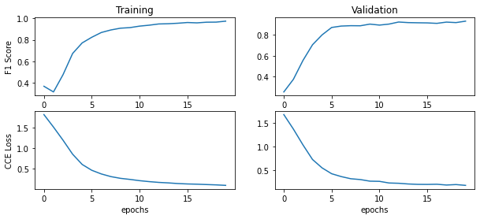

```python
from matplotlib import pyplot as plt

%matplotlib inline

plt.figure(figsize=(10,4))
plt.subplot(2,2,1)
plt.plot(mlp_histories[-1].history['f1_score'])

plt.ylabel('F1 Score')
plt.title('Training')
plt.subplot(2,2,2)
plt.plot(mlp_histories[-1].history['val_f1_score'])
plt.title('Validation')

plt.subplot(2,2,3)
plt.plot(mlp_histories[-1].history['loss'])
plt.ylabel('CCE Loss')
plt.xlabel('epochs')

plt.subplot(2,2,4)
plt.plot(mlp_histories[-1].history['val_loss'])
plt.xlabel('epochs')
```

```
MLP Average F1 score:  0.9362263083457947
```

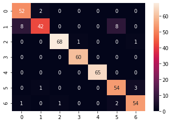

```python
print("MLP Average F1 score: ", np.mean([f1_score for [loss, f1_score] in mlp_scores]))

yhat_proba = mlp_models[-1].predict(X_test_cat + [X_test_num])
yhat = np.round(yhat_proba)
yhat = np.argmax(yhat, axis=1)

cm = mt.confusion_matrix(y_test, yhat)
sn.heatmap(cm, annot=True)
plt.show()
```

```python
from sklearn.metrics import classification_report

print(classification_report(y_test, yhat))
```

```
              precision    recall  f1-score   support

           0       0.85      0.96      0.90        54
           1       0.93      0.72      0.82        58
           2       0.99      0.97      0.98        70
           3       0.98      1.00      0.99        60
           4       1.00      1.00      1.00        65
           5       0.84      0.93      0.89        58
           6       0.93      0.93      0.93        58

    accuracy                           0.93       423
   macro avg       0.93      0.93      0.93       423
weighted avg       0.94      0.93      0.93       423
```

```python
y_test_mlp = y_test
yhat_proba_mlp = yhat_proba
yhat_mlp = yhat
```

## 2.2 Wide & Deep Networks

### 2.2.1. Wide & Deep Network 1 (Base Model) - 3 Deep Layers, 3 Crossed Columns

```python
def create_wide_and_deep_network_1(X_train, X_test):
    X_num_train = X_train[numerical_cols].values
    X_num_test = X_test[numerical_cols].values

    # save feature inputs to model
    X_cat_train = []
    X_cat_test = []

    # set crossed columns
    cross_columns = cross_columns_subset

    # cross all sets of columns
    cross_col_names = []
    for cols in cross_columns:
        # encode crossed column values as integers
        enc = LabelEncoder()

        X_crossed_train = X_train_orig[cols].apply(lambda x: '_'.join(x), axis=1)
        X_crossed_test = X_test_orig[cols].apply(lambda x: '_'.join(x), axis=1)

        enc.fit(np.hstack((X_crossed_train.to_numpy(), X_crossed_test.to_numpy())))

        # save into dataframe with new name
        cross_col_name = '_'.join(cols)
        X_train[cross_col_name] = enc.transform(X_crossed_train)
        X_test[cross_col_name] = enc.transform(X_crossed_test)
        X_cat_train.append(enc.transform(X_crossed_train))
        X_cat_test.append(enc.transform(X_crossed_test))

        cross_col_names.append(cross_col_name)

    # save crossed features
    X_train_crossed = X_train[cross_col_names].to_numpy()
    X_test_crossed = X_test[cross_col_names].to_numpy()

    # save categorical features
    X_train_cat = X_train[categorical_cols].to_numpy()
    X_test_cat = X_test[categorical_cols].to_numpy()

    # save numeric features
    X_train_num =  X_train[numerical_cols].to_numpy()
    X_test_num = X_test[numerical_cols].to_numpy()

    all_inputs = []

    # WIDE BRANCH - crossed data input
    wide_branch_outputs = []

    for idx, col in enumerate(cross_col_names):
        N = max(X_train[col].max(), X_test[col].max()) + 1

        # create / save crossed column inputs and embeddings
        inputs = Input(shape=(1,), dtype='int32', name=col)
        all_inputs.append(inputs)
        x = Embedding(input_dim=N, output_dim=int(np.sqrt(N)), input_length=1, name=col+'_embed')(inputs)
        x = Flatten()(x)

        wide_branch_outputs.append(x)

    # concatenate embeddings
    wide_branch = concatenate(wide_branch_outputs, name='wide_concat')
    wide_branch = Dense(units=15, activation='relu', name='wide_combined')(wide_branch)

    # DEEP BRANCH

    # deep network - categorical data input
    deep_branch_outputs = []

    for idx, col in enumerate(categorical_cols):
        X_cat_train.append(X_train[col].values)
        X_cat_test.append(X_test[col].values)

        # create / save categorical data inputs and embeddings
        N = max(X_train[col].max(), X_test[col].max()) + 1
        inputs = Input(shape=(1,), dtype='int32', name=col)
        all_inputs.append(inputs)
        x = Embedding(input_dim=N, output_dim=int(np.sqrt(N)), input_length=1, name=col+'_embed')(inputs)
        x = Flatten()(x)

        deep_branch_outputs.append(x)

    # deep network - numeric data input
    # create / save numeric data inputs and dense layer
    input_num = Input(shape=(X_train_num.shape[1],), name='numeric_inputs')
    all_inputs.append(input_num)

    x_dense = Dense(units=15, activation='relu', name='numeric_dense')(input_num)
    deep_branch_outputs.append(x_dense)

    # merge deep branches together
    deep_branch = concatenate(deep_branch_outputs, name='concat_deep')
    deep_branch = Dense(units=50, activation='relu', name='deep1')(deep_branch)
    deep_branch = Dense(units=25, activation='relu', name='deep2')(deep_branch)
    deep_branch = Dense(units=10, activation='relu', name='deep3')(deep_branch)

    # merge wide and deep branches together
    final_branch = concatenate([wide_branch, deep_branch], name='concat_deep_wide')
    final_branch = Dense(units=7, activation='softmax', name='combined')(final_branch)

    model = Model(inputs=all_inputs, outputs=final_branch, name='model1')

    return model, X_cat_train, X_num_train, X_cat_test, X_num_test
```

```python
# compute cross validation scores across all folds

X_num_train = X_train[numerical_cols].values
X_num_test = X_test[numerical_cols].values

wd_model1_scores = []
wd_model1_models = []
wd_model1_histories = []

for X_train_orig, X_test_orig, y_train_orig, y_test_orig in splits:
    X_train, X_test, y_train, y_test = preprocess_data(X_train_orig, X_test_orig, y_train_orig, y_test_orig)

    model1, X_cat_train, X_num_train, X_cat_test, X_num_test = create_wide_and_deep_network_1(X_train, X_test)
    model1.compile(optimizer='adam',
                  loss='categorical_crossentropy',
                  metrics=[f1])

    y_train_enc = y_train.reshape(len(y_train), 1)
    y_train_enc = y_ohe_encoder.transform(y_train_enc)
    y_test_enc = y_test.reshape(len(y_test), 1)
    y_test_enc = y_ohe_encoder.transform(y_test_enc)

    history = model1.fit(X_cat_train + [X_num_train],
                    y_train_enc,
                    epochs=20,
                    batch_size=32,
                    verbose=1,
                    validation_data = (X_cat_test + [X_num_test], y_test_enc))

    wd_model1_models.append(model1)
    wd_model1_histories.append(history)

    scores = model1.evaluate(X_cat_test + [X_num_test], y_test_enc, verbose=0)
    wd_model1_scores.append(scores)
```

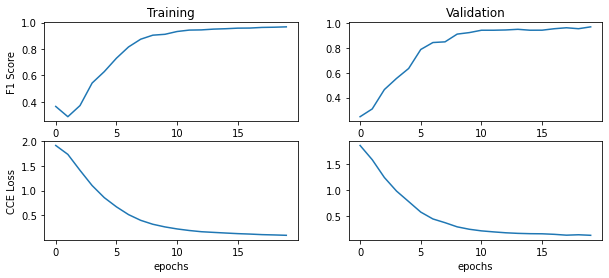

```python
# visualize f1 score and sparse categorical crossentropy loss

plt.figure(figsize=(10,4))
plt.subplot(2,2,1)
plt.plot(wd_model1_histories[-1].history['f1_score'])

plt.ylabel('F1 Score')
plt.title('Training')
plt.subplot(2,2,2)
plt.plot(wd_model1_histories[-1].history['val_f1_score'])
plt.title('Validation')

plt.subplot(2,2,3)
plt.plot(wd_model1_histories[-1].history['loss'])
plt.ylabel('CCE Loss')
plt.xlabel('epochs')

plt.subplot(2,2,4)
plt.plot(wd_model1_histories[-1].history['val_loss'])
plt.xlabel('epochs')
```

```
Wide & Deep Network Model 1 Average F1 score:  0.9500346899032592
```

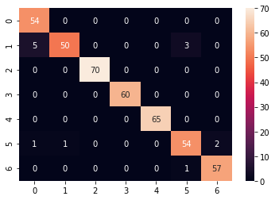

```python
print("Wide & Deep Network Model 1 Average F1 score: ", np.mean([f1_score for [loss, f1_score] in wd_model1_scores]))

yhat_proba = wd_model1_models[-1].predict(X_cat_test + [X_num_test])
yhat = np.round(yhat_proba)
yhat = np.argmax(yhat, axis=1)

cm = mt.confusion_matrix(y_test, yhat)
sn.heatmap(cm, annot=True)
plt.show()
```

```python
print(classification_report(y_test, yhat))
```

```
              precision    recall  f1-score   support

           0       0.90      1.00      0.95        54
           1       0.98      0.86      0.92        58
           2       1.00      1.00      1.00        70
           3       1.00      1.00      1.00        60
           4       1.00      1.00      1.00        65
           5       0.93      0.93      0.93        58
           6       0.97      0.98      0.97        58

    accuracy                           0.97       423
   macro avg       0.97      0.97      0.97       423
weighted avg       0.97      0.97      0.97       423
```

```python
y_test_model1 = y_test
yhat_proba_model1 = yhat_proba
yhat_model1 = yhat
```

### 2.2.2. Wide & Deep Network 2 - 3 Deep Layers, 5 Crossed Columns

```python
def create_wide_and_deep_network_2(X_train, X_test):
    X_num_train = X_train[numerical_cols].values
    X_num_test = X_test[numerical_cols].values

    # save feature inputs to model
    X_cat_train = []
    X_cat_test = []

    # set crossed columns
    cross_columns = cross_columns_all

    # cross all sets of columns
    cross_col_names = []
    for cols in cross_columns:
        # encode crossed column values as integers
        enc = LabelEncoder()

        X_crossed_train = X_train_orig[cols].apply(lambda x: '_'.join(x), axis=1)
        X_crossed_test = X_test_orig[cols].apply(lambda x: '_'.join(x), axis=1)

        enc.fit(np.hstack((X_crossed_train.to_numpy(), X_crossed_test.to_numpy())))

        # save into dataframe with new name
        cross_col_name = '_'.join(cols)
        X_train[cross_col_name] = enc.transform(X_crossed_train)
        X_test[cross_col_name] = enc.transform(X_crossed_test)
        X_cat_train.append(enc.transform(X_crossed_train))
        X_cat_test.append(enc.transform(X_crossed_test))

        cross_col_names.append(cross_col_name)

    # save crossed features
    X_train_crossed = X_train[cross_col_names].to_numpy()
    X_test_crossed = X_test[cross_col_names].to_numpy()

    # save categorical features
    X_train_cat = X_train[categorical_cols].to_numpy()
    X_test_cat = X_test[categorical_cols].to_numpy()

    # save numeric features
    X_train_num =  X_train[numerical_cols].to_numpy()
    X_test_num = X_test[numerical_cols].to_numpy()

    all_inputs = []

    # WIDE BRANCH - crossed data input
    wide_branch_outputs = []

    for idx, col in enumerate(cross_col_names):
        N = max(X_train[col].max(), X_test[col].max()) + 1

        # create / save crossed column inputs and embeddings
        inputs = Input(shape=(1,), dtype='int32', name=col)
        all_inputs.append(inputs)
        x = Embedding(input_dim=N, output_dim=int(np.sqrt(N)), input_length=1, name=col+'_embed')(inputs)
        x = Flatten()(x)

        wide_branch_outputs.append(x)

    # concatenate embeddings
    wide_branch = concatenate(wide_branch_outputs, name='wide_concat')
    wide_branch = Dense(units=15, activation='relu', name='wide_combined')(wide_branch)

    # DEEP BRANCH

    # deep network - categorical data input
    deep_branch_outputs = []

    for idx, col in enumerate(categorical_cols):
        X_cat_train.append(X_train[col].values)
        X_cat_test.append(X_test[col].values)

        # create / save categorical data inputs and embeddings
        N = max(X_train[col].max(), X_test[col].max()) + 1
        inputs = Input(shape=(1,), dtype='int32', name=col)
        all_inputs.append(inputs)
        x = Embedding(input_dim=N, output_dim=int(np.sqrt(N)), input_length=1, name=col+'_embed')(inputs)
        x = Flatten()(x)

        deep_branch_outputs.append(x)

    # deep network - numeric data input
    # create / save numeric data inputs and dense layer
    input_num = Input(shape=(X_train_num.shape[1],), name='numeric_inputs')
    all_inputs.append(input_num)

    x_dense = Dense(units=15, activation='relu', name='numeric_dense')(input_num)
    deep_branch_outputs.append(x_dense)

    # merge deep branches together
    deep_branch = concatenate(deep_branch_outputs, name='concat_deep')
    deep_branch = Dense(units=50, activation='relu', name='deep1')(deep_branch)
    deep_branch = Dense(units=25, activation='relu', name='deep2')(deep_branch)
    deep_branch = Dense(units=10, activation='relu', name='deep3')(deep_branch)

    # merge wide and deep branches together
    final_branch = concatenate([wide_branch, deep_branch], name='concat_deep_wide')
    final_branch = Dense(units=7, activation='softmax', name='combined')(final_branch)

    model = Model(inputs=all_inputs, outputs=final_branch, name='model2')

    return model, X_cat_train, X_num_train, X_cat_test, X_num_test
```

```python
# compute cross validation scores across all folds

wd_model2_scores = []
wd_model2_models = []
wd_model2_histories = []

for X_train_orig, X_test_orig, y_train_orig, y_test_orig in splits:
    X_train, X_test, y_train, y_test = preprocess_data(X_train_orig, X_test_orig, y_train_orig, y_test_orig)

    model2, X_cat_train, X_num_train, X_cat_test, X_num_test = create_wide_and_deep_network_2(X_train, X_test)
    model2.compile(optimizer='adam',
                  loss='categorical_crossentropy',
                  metrics=[f1])

    y_train_enc = y_train.reshape(len(y_train), 1)
    y_train_enc = y_ohe_encoder.transform(y_train_enc)
    y_test_enc = y_test.reshape(len(y_test), 1)
    y_test_enc = y_ohe_encoder.transform(y_test_enc)

    history = model2.fit(X_cat_train + [X_num_train],
                    y_train_enc,
                    epochs=20,
                    batch_size=32,
                    verbose=1,
                    validation_data = (X_cat_test + [X_num_test], y_test_enc))

    wd_model2_models.append(model2)
    wd_model2_histories.append(history)

    scores = model2.evaluate(X_cat_test + [X_num_test], y_test_enc, verbose=0)
    wd_model2_scores.append(scores)
```

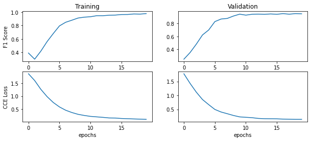

```python
# visualize f1 score and sparse categorical crossentropy loss

from matplotlib import pyplot as plt

%matplotlib inline

plt.figure(figsize=(10,4))
plt.subplot(2,2,1)
plt.plot(wd_model2_histories[-1].history['f1_score'])

plt.ylabel('F1 Score')
plt.title('Training')
plt.subplot(2,2,2)
plt.plot(wd_model2_histories[-1].history['val_f1_score'])
plt.title('Validation')

plt.subplot(2,2,3)
plt.plot(wd_model2_histories[-1].history['loss'])
plt.ylabel('CCE Loss')
plt.xlabel('epochs')

plt.subplot(2,2,4)
plt.plot(wd_model2_histories[-1].history['val_loss'])
plt.xlabel('epochs')
```

```
Wide & Deep Network Model 2 Average F1 score:  0.9418401122093201
```

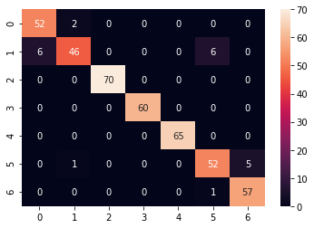

```python
print("Wide & Deep Network Model 2 Average F1 score: ", np.mean([f1_score for [loss, f1_score] in wd_model2_scores]))

yhat_proba = wd_model2_models[-1].predict(X_cat_test + [X_num_test])
yhat = np.round(yhat_proba)
yhat = np.argmax(yhat, axis=1)

cm = mt.confusion_matrix(y_test, yhat)
sn.heatmap(cm, annot=True)
plt.show()
```

```python
print(classification_report(y_test, yhat))
```

```
              precision    recall  f1-score   support

           0       0.90      0.96      0.93        54
           1       0.94      0.79      0.86        58
           2       1.00      1.00      1.00        70
           3       1.00      1.00      1.00        60
           4       1.00      1.00      1.00        65
           5       0.88      0.90      0.89        58
           6       0.92      0.98      0.95        58

    accuracy                           0.95       423
   macro avg       0.95      0.95      0.95       423
weighted avg       0.95      0.95      0.95       423
```

```python
y_test_model2 = y_test
yhat_proba_model2 = yhat_proba
yhat_model2 = yhat
```

### 2.2.3. Wide & Deep Network 3 - 3 Deep Layers (with 2x # of neurons), 3 Crossed Columns

```python
def create_wide_and_deep_network_3(X_train, X_test):
    X_num_train = X_train[numerical_cols].values
    X_num_test = X_test[numerical_cols].values

    # save feature inputs to model
    X_cat_train = []
    X_cat_test = []

    # set crossed columns
    cross_columns = cross_columns_subset

    # cross all sets of columns
    cross_col_names = []
    for cols in cross_columns:
        # encode crossed column values as integers
        enc = LabelEncoder()

        X_crossed_train = X_train_orig[cols].apply(lambda x: '_'.join(x), axis=1)
        X_crossed_test = X_test_orig[cols].apply(lambda x: '_'.join(x), axis=1)

        enc.fit(np.hstack((X_crossed_train.to_numpy(), X_crossed_test.to_numpy())))

        # save into dataframe with new name
        cross_col_name = '_'.join(cols)
        X_train[cross_col_name] = enc.transform(X_crossed_train)
        X_test[cross_col_name] = enc.transform(X_crossed_test)
        X_cat_train.append(enc.transform(X_crossed_train))
        X_cat_test.append(enc.transform(X_crossed_test))

        cross_col_names.append(cross_col_name)

    # save crossed features
    X_train_crossed = X_train[cross_col_names].to_numpy()
    X_test_crossed = X_test[cross_col_names].to_numpy()

    # save categorical features
    X_train_cat = X_train[categorical_cols].to_numpy()
    X_test_cat = X_test[categorical_cols].to_numpy()

    # save numeric features
    X_train_num =  X_train[numerical_cols].to_numpy()
    X_test_num = X_test[numerical_cols].to_numpy()

    all_inputs = []

    # WIDE BRANCH - crossed data input
    wide_branch_outputs = []

    for idx, col in enumerate(cross_col_names):
        N = max(X_train[col].max(), X_test[col].max()) + 1

        # create / save crossed column inputs and embeddings
        inputs = Input(shape=(1,), dtype='int32', name=col)
        all_inputs.append(inputs)
        x = Embedding(input_dim=N, output_dim=int(np.sqrt(N)), input_length=1, name=col+'_embed')(inputs)
        x = Flatten()(x)

        wide_branch_outputs.append(x)

    # concatenate embeddings
    wide_branch = concatenate(wide_branch_outputs, name='wide_concat')
    wide_branch = Dense(units=30, activation='relu', name='wide_combined')(wide_branch)

    # DEEP BRANCH

    # deep network - categorical data input
    deep_branch_outputs = []

    for idx, col in enumerate(categorical_cols):
        X_cat_train.append(X_train[col].values)
        X_cat_test.append(X_test[col].values)

        # create / save categorical data inputs and embeddings
        N = max(X_train[col].max(), X_test[col].max()) + 1
        inputs = Input(shape=(1,), dtype='int32', name=col)
        all_inputs.append(inputs)
        x = Embedding(input_dim=N, output_dim=int(np.sqrt(N)), input_length=1, name=col+'_embed')(inputs)
        x = Flatten()(x)

        deep_branch_outputs.append(x)

    # deep network - numeric data input
    # create / save numeric data inputs and dense layer
    input_num = Input(shape=(X_train_num.shape[1],), name='numeric_inputs')
    all_inputs.append(input_num)

    x_dense = Dense(units=15, activation='relu', name='numeric_dense')(input_num)
    deep_branch_outputs.append(x_dense)

    # merge deep branches together
    deep_branch = concatenate(deep_branch_outputs, name='concat_deep')
    deep_branch = Dense(units=100, activation='relu', name='deep1')(deep_branch)
    deep_branch = Dense(units=50, activation='relu', name='deep2')(deep_branch)
    deep_branch = Dense(units=20, activation='relu', name='deep3')(deep_branch)

    # merge wide and deep branches together
    final_branch = concatenate([wide_branch, deep_branch], name='concat_deep_wide')
    final_branch = Dense(units=7, activation='softmax', name='combined')(final_branch)

    model = Model(inputs=all_inputs, outputs=final_branch, name='model2')

    return model, X_cat_train, X_num_train, X_cat_test, X_num_test
```

```python
# compute cross validation scores across all folds

wd_model3_scores = []
wd_model3_models = []
wd_model3_histories = []

for X_train_orig, X_test_orig, y_train_orig, y_test_orig in splits:
    X_train, X_test, y_train, y_test = preprocess_data(X_train_orig, X_test_orig, y_train_orig, y_test_orig)

    model3, X_cat_train, X_num_train, X_cat_test, X_num_test = create_wide_and_deep_network_3(X_train, X_test)
    model3.compile(optimizer='adam',
                  loss='categorical_crossentropy',
                  metrics=[f1])

    y_train_enc = y_train.reshape(len(y_train), 1)
    y_train_enc = y_ohe_encoder.transform(y_train_enc)
    y_test_enc = y_test.reshape(len(y_test), 1)
    y_test_enc = y_ohe_encoder.transform(y_test_enc)

    history = model3.fit(X_cat_train + [X_num_train],
                    y_train_enc,
                    epochs=20,
                    batch_size=32,
                    verbose=1,
                    validation_data = (X_cat_test + [X_num_test], y_test_enc))

    wd_model3_models.append(model3)
    wd_model3_histories.append(history)

    scores = model3.evaluate(X_cat_test + [X_num_test], y_test_enc, verbose=0)
    wd_model3_scores.append(scores)
```

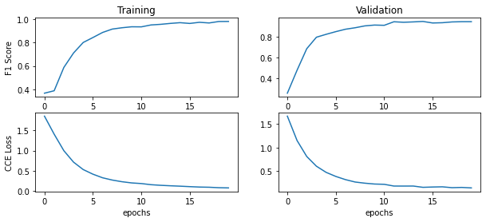

```python
# visualize f1 score and sparse categorical crossentropy loss

plt.figure(figsize=(10,4))
plt.subplot(2,2,1)
plt.plot(wd_model3_histories[-1].history['f1_score'])

plt.ylabel('F1 Score')
plt.title('Training')
plt.subplot(2,2,2)
plt.plot(wd_model3_histories[-1].history['val_f1_score'])
plt.title('Validation')

plt.subplot(2,2,3)
plt.plot(wd_model3_histories[-1].history['loss'])
plt.ylabel('CCE Loss')
plt.xlabel('epochs')

plt.subplot(2,2,4)
plt.plot(wd_model3_histories[-1].history['val_loss'])
plt.xlabel('epochs')
```

```
Wide & Deep Network Model 3 Average F1 score:  0.9438873410224915
```

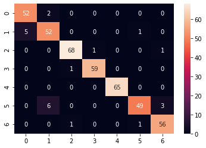

```python
print("Wide & Deep Network Model 3 Average F1 score: ", np.mean([f1_score for [loss, f1_score] in wd_model3_scores]))

yhat_proba = wd_model3_models[-1].predict(X_cat_test + [X_num_test])
yhat = np.round(yhat_proba)
yhat = np.argmax(yhat, axis=1)

cm = mt.confusion_matrix(y_test,yhat)
sn.heatmap(cm, annot=True)
plt.show()
```

```python
print(classification_report(y_test, yhat))
```

```
              precision    recall  f1-score   support

           0       0.91      0.96      0.94        54
           1       0.87      0.90      0.88        58
           2       0.97      0.97      0.97        70
           3       0.98      0.98      0.98        60
           4       1.00      1.00      1.00        65
           5       0.96      0.84      0.90        58
           6       0.93      0.97      0.95        58

    accuracy                           0.95       423
   macro avg       0.95      0.95      0.95       423
weighted avg       0.95      0.95      0.95       423
```

```python
y_test_model3 = y_test
yhat_proba_model3 = yhat_proba
yhat_model3 = yhat
```

### 2.2.4. Wide & Deep Network 4 - 5 Deep Layers, 3 Crossed Columns

```python
def create_wide_and_deep_network_4(X_train, X_test):
    X_num_train = X_train[numerical_cols].values
    X_num_test = X_test[numerical_cols].values

    # save feature inputs to model
    X_cat_train = []
    X_cat_test = []

    # set crossed columns
    cross_columns = cross_columns_subset

    # cross all sets of columns
    cross_col_names = []
    for cols in cross_columns:
        # encode crossed column values as integers
        enc = LabelEncoder()

        X_crossed_train = X_train_orig[cols].apply(lambda x: '_'.join(x), axis=1)
        X_crossed_test = X_test_orig[cols].apply(lambda x: '_'.join(x), axis=1)

        enc.fit(np.hstack((X_crossed_train.to_numpy(), X_crossed_test.to_numpy())))

        # save into dataframe with new name
        cross_col_name = '_'.join(cols)
        X_train[cross_col_name] = enc.transform(X_crossed_train)
        X_test[cross_col_name] = enc.transform(X_crossed_test)
        X_cat_train.append(enc.transform(X_crossed_train))
        X_cat_test.append(enc.transform(X_crossed_test))

        cross_col_names.append(cross_col_name)

    # save crossed features
    X_train_crossed = X_train[cross_col_names].to_numpy()
    X_test_crossed = X_test[cross_col_names].to_numpy()

    # save categorical features
    X_train_cat = X_train[categorical_cols].to_numpy()
    X_test_cat = X_test[categorical_cols].to_numpy()

    # save numeric features
    X_train_num =  X_train[numerical_cols].to_numpy()
    X_test_num = X_test[numerical_cols].to_numpy()

    all_inputs = []

    # WIDE BRANCH - crossed data input
    wide_branch_outputs = []

    for idx, col in enumerate(cross_col_names):
        N = max(X_train[col].max(), X_test[col].max()) + 1

        # create / save crossed column inputs and embeddings
        inputs = Input(shape=(1,), dtype='int32', name=col)
        all_inputs.append(inputs)
        x = Embedding(input_dim=N, output_dim=int(np.sqrt(N)), input_length=1, name=col+'_embed')(inputs)
        x = Flatten()(x)

        wide_branch_outputs.append(x)

    # concatenate embeddings
    wide_branch = concatenate(wide_branch_outputs, name='wide_concat')
    wide_branch = Dense(units=15, activation='relu', name='wide_combined')(wide_branch)

    # DEEP BRANCH

    # deep network - categorical data input
    deep_branch_outputs = []

    for idx, col in enumerate(categorical_cols):
        X_cat_train.append(X_train[col].values)
        X_cat_test.append(X_test[col].values)

        # create / save categorical data inputs and embeddings
        N = max(X_train[col].max(), X_test[col].max()) + 1
        inputs = Input(shape=(1,), dtype='int32', name=col)
        all_inputs.append(inputs)
        x = Embedding(input_dim=N, output_dim=int(np.sqrt(N)), input_length=1, name=col+'_embed')(inputs)
        x = Flatten()(x)

        deep_branch_outputs.append(x)

    # deep network - numeric data input
    # create / save numeric data inputs and dense layer
    input_num = Input(shape=(X_train_num.shape[1],), name='numeric_inputs')
    all_inputs.append(input_num)

    x_dense = Dense(units=15, activation='relu', name='numeric_dense')(input_num)
    deep_branch_outputs.append(x_dense)

    # merge deep branches together
    deep_branch = concatenate(deep_branch_outputs, name='concat_deep')

    # CHANGE NUMBER OF BRANCHES IN DEEP NETWORK
    deep_branch = Dense(units=50, activation='relu', name='deep1')(deep_branch)
    deep_branch = Dense(units=50, activation='relu', name='deep2')(deep_branch)
    deep_branch = Dense(units=25, activation='relu', name='deep3')(deep_branch)
    deep_branch = Dense(units=25, activation='relu', name='deep4')(deep_branch)
    deep_branch = Dense(units=10, activation='relu', name='deep5')(deep_branch)

    # merge wide and deep branches together
    final_branch = concatenate([wide_branch, deep_branch], name='concat_deep_wide')
    final_branch = Dense(units=7, activation='softmax', name='combined')(final_branch)

    model = Model(inputs=all_inputs, outputs=final_branch, name='model4')

    return model, X_cat_train, X_num_train, X_cat_test, X_num_test
```

```python
# compute cross validation scores across all folds

wd_model4_scores = []
wd_model4_models = []
wd_model4_histories = []

for X_train_orig, X_test_orig, y_train_orig, y_test_orig in splits:
    X_train, X_test, y_train, y_test = preprocess_data(X_train_orig, X_test_orig, y_train_orig, y_test_orig)

    model4, X_cat_train, X_num_train, X_cat_test, X_num_test = create_wide_and_deep_network_4(X_train, X_test)
    model4.compile(optimizer='adam',
                  loss='categorical_crossentropy',
                  metrics=[f1])

    y_train_enc = y_train.reshape(len(y_train), 1)
    y_train_enc = y_ohe_encoder.transform(y_train_enc)
    y_test_enc = y_test.reshape(len(y_test), 1)
    y_test_enc = y_ohe_encoder.transform(y_test_enc)

    history = model4.fit(X_cat_train + [X_num_train],
                    y_train_enc,
                    epochs=20,
                    batch_size=32,
                    verbose=1,
                    validation_data = (X_cat_test + [X_num_test], y_test_enc))

    wd_model4_models.append(model4)
    wd_model4_histories.append(history)

    scores = model4.evaluate(X_cat_test + [X_num_test], y_test_enc, verbose=0)
    wd_model4_scores.append(scores)
```

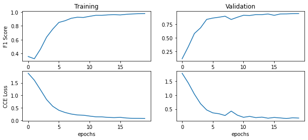

```python
# visualize f1 score and sparse categorical crossentropy loss

plt.figure(figsize=(10,4))
plt.subplot(2,2,1)
plt.plot(wd_model4_histories[-1].history['f1_score'])

plt.ylabel('F1 Score')
plt.title('Training')
plt.subplot(2,2,2)
plt.plot(wd_model4_histories[-1].history['val_f1_score'])
plt.title('Validation')

plt.subplot(2,2,3)
plt.plot(wd_model4_histories[-1].history['loss'])
plt.ylabel('CCE Loss')
plt.xlabel('epochs')

plt.subplot(2,2,4)
plt.plot(wd_model4_histories[-1].history['val_loss'])
plt.xlabel('epochs')
```

```
Wide & Deep Network Model 4 Average F1 Score:  0.9413455247879028
```

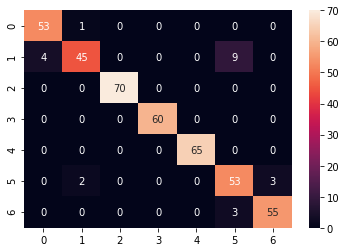

```python
print("Wide & Deep Network Model 4 Average F1 Score: ", np.mean([score for [loss, score] in wd_model4_scores]))

yhat_proba = wd_model4_models[-1].predict(X_cat_test + [X_num_test])
yhat = np.round(yhat_proba)
yhat = np.argmax(yhat, axis=1)

cm = mt.confusion_matrix(y_test, yhat)
sn.heatmap(cm, annot=True)
plt.show()
```

```python
print(classification_report(y_test, yhat))
```

```
              precision    recall  f1-score   support

           0       0.93      0.98      0.95        54
           1       0.94      0.78      0.85        58
           2       1.00      1.00      1.00        70
           3       1.00      1.00      1.00        60
           4       1.00      1.00      1.00        65
           5       0.82      0.91      0.86        58
           6       0.95      0.95      0.95        58

    accuracy                           0.95       423
   macro avg       0.95      0.95      0.94       423
weighted avg       0.95      0.95      0.95       423
```

```python
y_test_model4 = y_test
yhat_proba_model4 = yhat_proba
yhat_model4 = yhat
```

### 2.2.5 Wide & Deep Network 5 - 7 Deep Layers, 3 Crossed Columns

```python
def create_wide_and_deep_network_5(X_train, X_test):
    X_num_train = X_train[numerical_cols].values
    X_num_test = X_test[numerical_cols].values

    # save feature inputs to model
    X_cat_train = []
    X_cat_test = []

    # set crossed columns
    cross_columns = cross_columns_subset

    # cross all sets of columns
    cross_col_names = []
    for cols in cross_columns:
        # encode crossed column values as integers
        enc = LabelEncoder()

        X_crossed_train = X_train_orig[cols].apply(lambda x: '_'.join(x), axis=1)
        X_crossed_test = X_test_orig[cols].apply(lambda x: '_'.join(x), axis=1)

        enc.fit(np.hstack((X_crossed_train.to_numpy(), X_crossed_test.to_numpy())))

        # save into dataframe with new name
        cross_col_name = '_'.join(cols)
        X_train[cross_col_name] = enc.transform(X_crossed_train)
        X_test[cross_col_name] = enc.transform(X_crossed_test)
        X_cat_train.append(enc.transform(X_crossed_train))
        X_cat_test.append(enc.transform(X_crossed_test))

        cross_col_names.append(cross_col_name)

    # save crossed features
    X_train_crossed = X_train[cross_col_names].to_numpy()
    X_test_crossed = X_test[cross_col_names].to_numpy()

    # save categorical features
    X_train_cat = X_train[categorical_cols].to_numpy()
    X_test_cat = X_test[categorical_cols].to_numpy()

    # save numeric features
    X_train_num =  X_train[numerical_cols].to_numpy()
    X_test_num = X_test[numerical_cols].to_numpy()

    all_inputs = []

    # WIDE BRANCH - crossed data input
    wide_branch_outputs = []

    for idx, col in enumerate(cross_col_names):
        N = max(X_train[col].max(), X_test[col].max()) + 1

        # create / save crossed column inputs and embeddings
        inputs = Input(shape=(1,), dtype='int32', name=col)
        all_inputs.append(inputs)
        x = Embedding(input_dim=N, output_dim=int(np.sqrt(N)), input_length=1, name=col+'_embed')(inputs)
        x = Flatten()(x)

        wide_branch_outputs.append(x)

    # concatenate embeddings
    wide_branch = concatenate(wide_branch_outputs, name='wide_concat')
    wide_branch = Dense(units=15, activation='relu', name='wide_combined')(wide_branch)

    # DEEP BRANCH

    # deep network - categorical data input
    deep_branch_outputs = []

    for idx, col in enumerate(categorical_cols):
        X_cat_train.append(X_train[col].values)
        X_cat_test.append(X_test[col].values)

        # create / save categorical data inputs and embeddings
        N = max(X_train[col].max(), X_test[col].max()) + 1
        inputs = Input(shape=(1,), dtype='int32', name=col)
        all_inputs.append(inputs)
        x = Embedding(input_dim=N, output_dim=int(np.sqrt(N)), input_length=1, name=col+'_embed')(inputs)
        x = Flatten()(x)

        deep_branch_outputs.append(x)

    # deep network - numeric data input
    # create / save numeric data inputs and dense layer
    input_num = Input(shape=(X_train_num.shape[1],), name='numeric_inputs')
    all_inputs.append(input_num)

    x_dense = Dense(units=15, activation='relu', name='numeric_dense')(input_num)
    deep_branch_outputs.append(x_dense)

    # merge deep branches together
    deep_branch = concatenate(deep_branch_outputs, name='concat_deep')

    # CHANGE NUMBER OF BRANCHES IN DEEP NETWORK
    deep_branch = Dense(units=100, activation='relu', name='deep1')(deep_branch)
    deep_branch = Dense(units=50, activation='relu', name='deep2')(deep_branch)
    deep_branch = Dense(units=50, activation='relu', name='deep3')(deep_branch)
    deep_branch = Dense(units=25, activation='relu', name='deep4')(deep_branch)
    deep_branch = Dense(units=25, activation='relu', name='deep5')(deep_branch)
    deep_branch = Dense(units=10, activation='relu', name='deep6')(deep_branch)
    deep_branch = Dense(units=10, activation='relu', name='deep7')(deep_branch)

    # merge wide and deep branches together
    final_branch = concatenate([wide_branch, deep_branch], name='concat_deep_wide')
    final_branch = Dense(units=7, activation='softmax', name='combined')(final_branch)

    model = Model(inputs=all_inputs, outputs=final_branch, name='model5')

    return model, X_cat_train, X_num_train, X_cat_test, X_num_test
```

```python
# compute cross validation scores across all folds

wd_model5_scores = []
wd_model5_models = []
wd_model5_histories = []

for X_train_orig, X_test_orig, y_train_orig, y_test_orig in splits:
    X_train, X_test, y_train, y_test = preprocess_data(X_train_orig, X_test_orig, y_train_orig, y_test_orig)

    model5, X_cat_train, X_num_train, X_cat_test, X_num_test = create_wide_and_deep_network_5(X_train, X_test)
    model5.compile(optimizer='adam',
                  loss='categorical_crossentropy',
                  metrics=[f1])

    y_train_enc = y_train.reshape(len(y_train), 1)
    y_train_enc = y_ohe_encoder.transform(y_train_enc)
    y_test_enc = y_test.reshape(len(y_test), 1)
    y_test_enc = y_ohe_encoder.transform(y_test_enc)

    history = model5.fit(X_cat_train + [X_num_train],
                    y_train_enc,
                    epochs=20,
                    batch_size=32,
                    verbose=1,
                    validation_data = (X_cat_test + [X_num_test], y_test_enc))

    wd_model5_models.append(model5)
    wd_model5_histories.append(history)

    scores = model5.evaluate(X_cat_test + [X_num_test], y_test_enc, verbose=0)
    wd_model5_scores.append(scores)
```

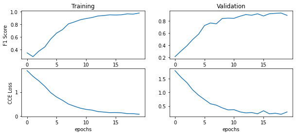

```python
# visualize f1 score and sparse categorical crossentropy loss

plt.figure(figsize=(10,4))
plt.subplot(2,2,1)
plt.plot(wd_model5_histories[-1].history['f1_score'])

plt.ylabel('F1 Score')
plt.title('Training')
plt.subplot(2,2,2)
plt.plot(wd_model5_histories[-1].history['val_f1_score'])
plt.title('Validation')

plt.subplot(2,2,3)
plt.plot(wd_model5_histories[-1].history['loss'])
plt.ylabel('CCE Loss')
plt.xlabel('epochs')

plt.subplot(2,2,4)
plt.plot(wd_model5_histories[-1].history['val_loss'])
plt.xlabel('epochs')
```

```
Wide & Deep Network Model 5 Average F1 Score:  0.9181435704231262
```

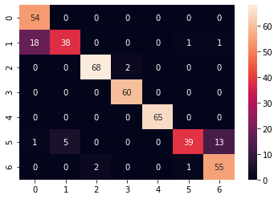

```python
print("Wide & Deep Network Model 5 Average F1 Score: ", np.mean([score for [loss, score] in wd_model5_scores]))

yhat_proba = wd_model5_models[-1].predict(X_cat_test + [X_num_test])
yhat = np.round(yhat_proba)
yhat = np.argmax(yhat, axis=1)

cm = mt.confusion_matrix(y_test, yhat)
sn.heatmap(cm, annot=True)
plt.show()
```

```python
print(classification_report(y_test, yhat))
```

```
              precision    recall  f1-score   support

           0       0.74      1.00      0.85        54
           1       0.88      0.66      0.75        58
           2       0.97      0.97      0.97        70
           3       0.97      1.00      0.98        60
           4       1.00      1.00      1.00        65
           5       0.95      0.67      0.79        58
           6       0.80      0.95      0.87        58

    accuracy                           0.90       423
   macro avg       0.90      0.89      0.89       423
weighted avg       0.91      0.90      0.89       423
```

```python
y_test_model5 = y_test
yhat_proba_model5 = yhat_proba
yhat_model5 = yhat
```

## 2.3 Compare model architectures with different numbers of deep branch layers

Here, we compare wide & deep models #1, #4, and #5, which only differ in the number of deep branch layers (3, 5, and 7 respectively) using the McNemar's statistical significance test. McNemar's test is a statistical signifiance test that can be used to compare the performance of different machine learning models. The test is "recommended in those cases where the algorithms being compared can only be evaluated once" [[ref](https://machinelearningmastery.com/mcnemars-test-for-machine-learning/)]. We use this test to determine whether one model's performance is significantly different from another model's performance by calculating a contingency table and comparing the calculated `pvalue` to a specified `alpha`.

Reference: https://en.wikipedia.org/wiki/McNemar%27s_test

```python
def calculate_contingency_table(cl1_array, cl2_array):
    table = np.zeros((2, 2))

    # [[both correct, cl1 correct and cl2 wrong]
    # [cl2 correct and cl1 wrong, both cl1 and cl2 wrong]]

    for r1, r2 in zip(cl1_array, cl2_array):
        if r1 and r2:
            table[0][0] += 1
        elif r1 and not r2:
            table[0][1] += 1
        elif not r1 and r2:
            table[1][0] += 1
        else:
            table[1][1] += 1

    return table
```

```python
cl1_correct = y_test_model1 == yhat_model1
cl2_correct = y_test_model2 == yhat_model2
cl3_correct = y_test_model3 == yhat_model3
cl4_correct = y_test_model4 == yhat_model4
cl5_correct = y_test_model5 == yhat_model5
mlp_correct = y_test_mlp == yhat_mlp

cl1_cl4_ct = calculate_contingency_table(cl1_correct, cl4_correct)
cl1_cl5_ct = calculate_contingency_table(cl1_correct, cl5_correct)
cl4_cl5_ct = calculate_contingency_table(cl4_correct, cl5_correct)

cl1_cl2_ct = calculate_contingency_table(cl1_correct, cl2_correct)
cl1_cl3_ct = calculate_contingency_table(cl1_correct, cl3_correct)
cl2_cl3_ct = calculate_contingency_table(cl2_correct, cl3_correct)
```

```python
from statsmodels.stats.contingency_tables import mcnemar
alpha = 0.05

# code adapted from https://machinelearningmastery.com/mcnemars-test-for-machine-learning/
def mcnemar_test(table):
    # calculate mcnemar test from contingency table and print out statistical results
    result = mcnemar(table, exact=True)
    print('statistic=%.3f, p-value=%.3f' % (result.statistic, result.pvalue))

    # interpret the p-value
    if result.pvalue > alpha:
        print('Same proportions of errors (fail to reject H0)')
    else:
        print('Different proportions of errors (reject H0)')
```

```python
print("Classifier 1 (C1): 3 Deep Layers, 3 Crossed Columns")
print("Classifier 4 (C4): 5 Deep Layers, 3 Crossed Columns")
print("Classifier 5 (C5): 7 Deep Layers, 3 Crossed Columns")
print()

print("C1 and C4:")
mcnemar_test(cl1_cl4_ct)
print()

print("C1 and C5:")
mcnemar_test(cl1_cl5_ct)
print()

print("C4 and C5:")
mcnemar_test(cl4_cl5_ct)
print()
```

```
Classifier 1 (C1): 3 Deep Layers, 3 Crossed Columns
Classifier 4 (C4): 5 Deep Layers, 3 Crossed Columns
Classifier 5 (C5): 7 Deep Layers, 3 Crossed Columns

C1 and C4:
statistic=2.000, p-value=0.022
Different proportions of errors (reject H0)

C1 and C5:
statistic=6.000, p-value=0.000
Different proportions of errors (reject H0)

C4 and C5:
statistic=11.000, p-value=0.001
Different proportions of errors (reject H0)
```

```python
# [[both correct, cl1 correct and cl4 wrong]
# [cl4 correct and cl1 wrong, both cl1 and cl4 wrong]]

cl1_cl4_ct
```

```
array([[399.,  11.],
       [  2.,  11.]])
```

```python
# [[both correct, cl1 correct and cl5 wrong]
# [cl5 correct and cl1 wrong, both cl1 and cl5 wrong]]

cl1_cl5_ct
```

```
array([[373.,  37.],
       [  6.,   7.]])
```

```python
# [[both correct, cl4 correct and cl5 wrong]
# [cl5 correct and cl4 wrong, both cl4 and cl5 wrong]]

cl4_cl5_ct
```

```
array([[368.,  33.],
       [ 11.,  11.]])
```

The McNemar test demonstrates that models 1, 4, and 5 are all statistically different from one another. The contingency matrices printed above show that model 1 is correct more when the other two models are wrong compared to the instances in which the other two models are correct when model 1 is wrong. Because of this, we select model 1 as the best in terms of number of deep layers (3) to include.

```python
print("Classifier 1 (C1): 3 Deep Layers, 3 Crossed Columns")
print("Classifier 2 (C2): 3 Deep Layers, 5 Crossed Columns")
print("Classifier 3 (C3): 3 Deep Layers (2x # of neurons), 3 Crossed Columns")
print()

print("C1 and C2:")
mcnemar_test(cl1_cl2_ct)
print()

print("C1 and C3:")
mcnemar_test(cl1_cl3_ct)
print()

print("C2 and C3:")
mcnemar_test(cl2_cl3_ct)
print()
```

```
Classifier 1 (C1): 3 Deep Layers, 3 Crossed Columns
Classifier 2 (C2): 3 Deep Layers, 5 Crossed Columns
Classifier 3 (C3): 3 Deep Layers (2x # of neurons), 3 Crossed Columns

C1 and C2:
statistic=2.000, p-value=0.039
Different proportions of errors (reject H0)

C1 and C3:
statistic=6.000, p-value=0.078
Same proportions of errors (fail to reject H0)

C2 and C3:
statistic=13.000, p-value=1.000
Same proportions of errors (fail to reject H0)
```

```python
# [[both correct, cl1 correct and cl2 wrong]
# [cl2 correct and cl1 wrong, both cl1 and cl2 wrong]]

cl1_cl2_ct
```

```
array([[400.,  10.],
       [  2.,  11.]])
```

We will compare our MLP with model #1 in the next section of our report using ROC and AUC metrics / curves.

### 2.3 Compare MLP vs. Best Wide & Deep Model

Here, we compare our MLP and best wide & deep model (#1) using the receiver operating characteristic and area under the curve values. The ROC curve shows the performance of a classification model at all classification thresholds based on true positive and false positive rates at different classification thresholds. The area under the curve (or AUC) is the area under the ROC curve and "provides an aggregate measure of perofmrance across all possible classification thresholds." Generally, the greater the AUC is, the better the model is.

We plot the micro-averaged ROC curves across all classes for the multiclass classification problem.

References: https://developers.google.com/machine-learning/crash-course/classification/roc-and-auc

```python
# Compute ROC curve and ROC area for each class
# Code & Reference: https://scikit-learn.org/stable/auto_examples/model_selection/plot_roc.html
from sklearn.metrics import roc_curve, auc

n_classes = 7

# compute ROC curve and ROC area for each class for each model
fpr_model1 = dict()
tpr_model1 = dict()
roc_auc_model1 = dict()

y_test_model1_expanded = y_ohe_encoder.transform(y_test_model1.reshape(-1, 1))

for i in range(n_classes):
    fpr_model1[i], tpr_model1[i], _ = roc_curve(y_test_model1_expanded[:,i], yhat_proba_model1[:, i])
    roc_auc_model1[i] = auc(fpr_model1[i], tpr_model1[i])

fpr_mlp = dict()
tpr_mlp = dict()
roc_auc_mlp = dict()

y_test_mlp_expanded = y_ohe_encoder.transform(y_test_mlp.reshape(-1, 1))

for i in range(n_classes):
    fpr_mlp[i], tpr_mlp[i], _ = roc_curve(y_test_mlp_expanded[:,i], yhat_proba_mlp[:, i])
    roc_auc_mlp[i] = auc(fpr_mlp[i], tpr_mlp[i])
```

```python
# compute micro-average ROC curve and ROC area

fpr_model1["micro"], tpr_model1["micro"], _ = roc_curve(y_test_model1_expanded.ravel(), yhat_proba_model1.ravel())
fpr_mlp["micro"], tpr_mlp["micro"], _ = roc_curve(y_test_mlp_expanded.ravel(), yhat_proba_mlp.ravel())

roc_auc_model1["micro"] = auc(fpr_model1["micro"], tpr_model1["micro"])
roc_auc_mlp["micro"] = auc(fpr_mlp["micro"], tpr_mlp["micro"])
```

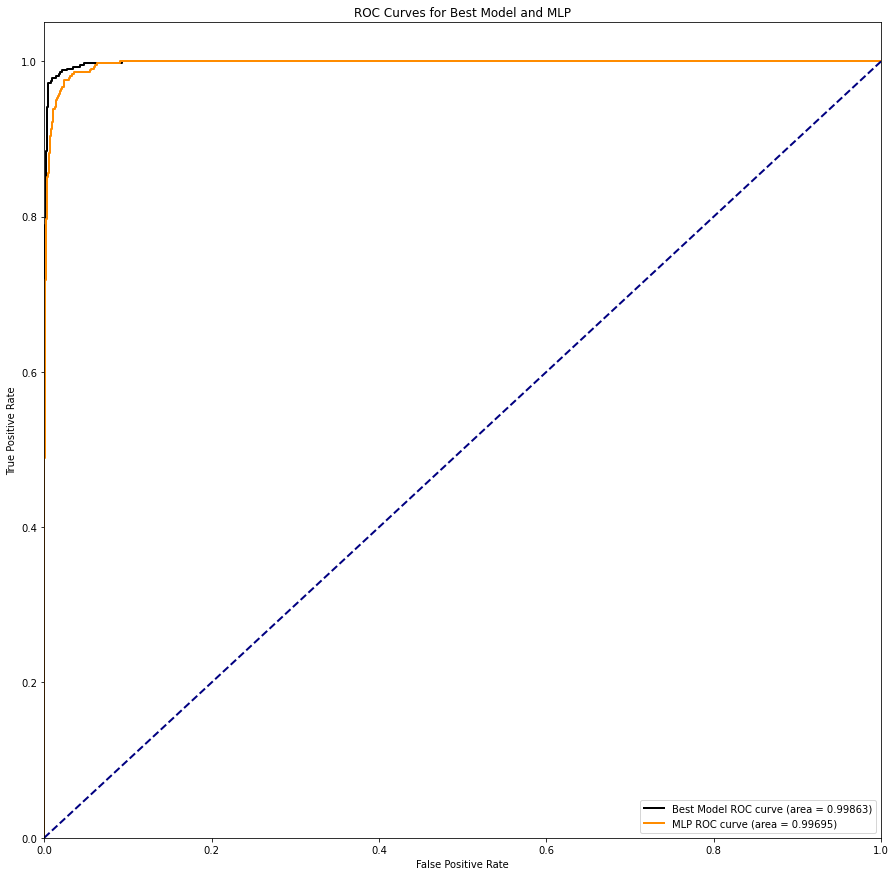

```python
plt.figure(figsize=(15, 15))
lw = 2

plt.plot(fpr_model1["micro"], tpr_model1["micro"], color='black',
         lw=lw, label='Best Model ROC curve (area = %0.5f)' % roc_auc_model1["micro"])

plt.plot(fpr_mlp["micro"], tpr_mlp["micro"], color='darkorange',
         lw=lw, label='MLP ROC curve (area = %0.5f)' % roc_auc_mlp["micro"])

plt.plot([0, 1], [0, 1], color='navy', lw=lw, linestyle='--')
plt.xlim([0.0, 1.0])
plt.ylim([0.0, 1.05])
plt.xlabel('False Positive Rate')
plt.ylabel('True Positive Rate')
plt.title('ROC Curves for Best Model and MLP')
plt.legend(loc="lower right")
plt.show()
```

```python
cl1_mlp_ct = calculate_contingency_table(cl1_correct, mlp_correct)
print("Classifier 1 (C1): 3 Deep Layers, 3 Crossed Columns")
print("Multi-Layer Perceptron Classifier")
print()

print("C1 and MLP:")
mcnemar_test(cl1_mlp_ct)
print()
```

```
Classifier 1 (C1): 3 Deep Layers, 3 Crossed Columns
Multi-Layer Perceptron Classifier

C1 and MLP:
statistic=2.000, p-value=0.001
Different proportions of errors (reject H0)
```

```python
# [[both correct, cl1 correct and mlp wrong]
# [mlp correct and cl1 wrong, both cl1 and mlp wrong]]

cl1_mlp_ct
```

```
array([[393.,  17.],
       [  2.,  11.]])
```

The micro-averaged ROC curves for our best model and the MLP model show that though it is difficult to tell which model performs better, the ROC curve for our best model is above that of our MLP model at most points, while the reverse is true very rarely along the TPR - FPR curve. The AUC of our best model is also greater than the AUC of our MLP. A statistical McNemar's test shows the same - we reject the null hypothesis, meaning that the two models do perform statistically differently, with our best wide and deep network performing better.

## 3. Exceptional Work

```python
# Reference: https://keras.io/api/layers/base_layer/#weights-property

count = 0
weightsHold = []
for layers in wd_model3_models[-1].layers:
    print(layers)
    print(layers.name)
    if '_embed' in layers.name:
        count += 1
        print(layers.get_weights()[0])
        weightsHold.append(layers.get_weights()[0])
        if count == 8:
            break
    print()
```

[output not shown]

[output cut: 15 more lines]

```

<tensorflow.python.keras.layers.embeddings.Embedding object at 0x7ff8bb457f50>
CALC_embed
[[ 0.10580692  0.12024903]
 [ 0.10477744 -0.08805984]
 [ 0.15388253 -0.21521197]
 [-0.0537368   0.31793627]]

<tensorflow.python.keras.layers.embeddings.Embedding object at 0x7ff8b5d40790>
MTRANS_embed
[[-0.03477341  0.29777607]
 [ 0.22277433  0.18381062]
 [-0.01769174 -0.01796996]
 [ 0.18558326  0.22499755]
 [-0.06553162 -0.01400572]]
```

```python
# Reference: https://scikit-learn.org/stable/modules/generated/sklearn.manifold.TSNE.html
from sklearn.manifold import TSNE

t = TSNE(n_components=2)
tsneWeights=[]
for w in weightsHold:
    embeddings = t.fit_transform(w)
    tsneWeights.append(embeddings)
    print(embeddings)
    print(embeddings[:, 0])
    print(embeddings.shape)
    print()
```

```
[[ 21655.117  10255.9  ]
 [-21655.117 -10255.9  ]]
[ 21655.117 -21655.117]
(2, 2)

[[-662.8992   724.1995 ]
 [ 662.8994  -724.19977]]
[-662.8992  662.8994]
(2, 2)

[[  8657.202  18494.3  ]
 [ -8657.202 -18494.3  ]]
[ 8657.202 -8657.202]
(2, 2)

[[ -14.107761  461.19757 ]
 [  14.107548 -461.19757 ]]
[-14.107761  14.107548]
(2, 2)

[[-1015.68536   993.88684]
 [ 1015.68536  -993.8871 ]]
[-1015.68536  1015.68536]
(2, 2)

[[ 126.23868  270.0631 ]
 [  67.04743 -231.73215]
 [ 347.55795  -10.43218]
 [-154.27179   48.76321]]
[ 126.23868   67.04743  347.55795 -154.27179]
(4, 2)

[[ 114.506676   91.002075]
 [ -47.156433  -95.56097 ]
 [ 139.40807  -257.2224  ]
 [ 301.07114   -70.65938 ]]
[114.506676 -47.156433 139.40807  301.07114 ]
(4, 2)

[[ 163.34613   120.08961 ]
 [-155.82361    57.933704]
 [  19.597975  242.8601  ]
 [-169.17181   253.04721 ]
 [  19.188955  -12.072774]]
[ 163.34613  -155.82361    19.597975 -169.17181    19.188955]
(5, 2)
```

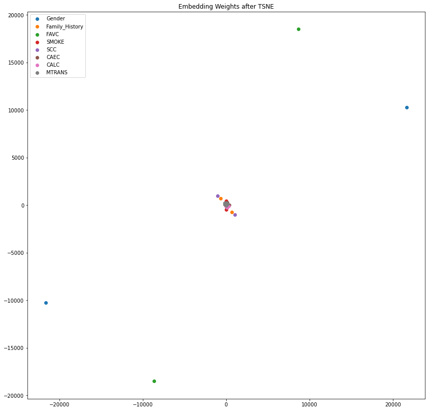

```python
# References:
# https://www.tutorialspoint.com/matplotlib/matplotlib_scatter_plot.htm
# https://pythonspot.com/matplotlib-scatterplot/

plt.figure(figsize=(14,14))
countName = 0
plt.title('Embedding Weights after TSNE')

for x in tsneWeights:
    plt.scatter(x[:,0], x[:,1], label=categorical_cols[countName])
    countName += 1

plt.legend(loc=2)
plt.show()
```